# Inference for Means using Normal Distributions

Day 21

Claire Kelling

Carleton College  
STAT 120 - Fall 2026

## Question of the Day

What did you want to be when you grew up when you were younger? 😊

## Today’s Topics

Project Topics:

- AI for quiz preparation
- Participation plug!
- Proposals due this evening!
- Short report feedback
- Pink sheets!
- Please carefully follow assignment guidelines

Topics covered today:

- Inference for Means using Normal Distributions

## Central Limit Theorem for means

**One Sample**

The sampling distribution for a sample mean is  
approximately $N(\mu, SE_{\bar{x}})$

When is this approximately “good”?

- Small $n$ ok if population distribution is symmetric (generally want $n \geq 30$)
- Larger $n$ needed the more skewed the population

**Two Samples**

The sampling distribution for a difference of **two independent sample means** is approximately $N(\mu_1 - \mu_2, SE_{\bar{x}_1 - \bar{x}_2})$

When is this approximately “good”?

- Need both $n_1$ and $n_2$ sample sizes big enough for the one-sample condition

# Simulated Examples

## Simulated Example

Population of responses is very right skewed with a population mean of $\mu = 0.998$

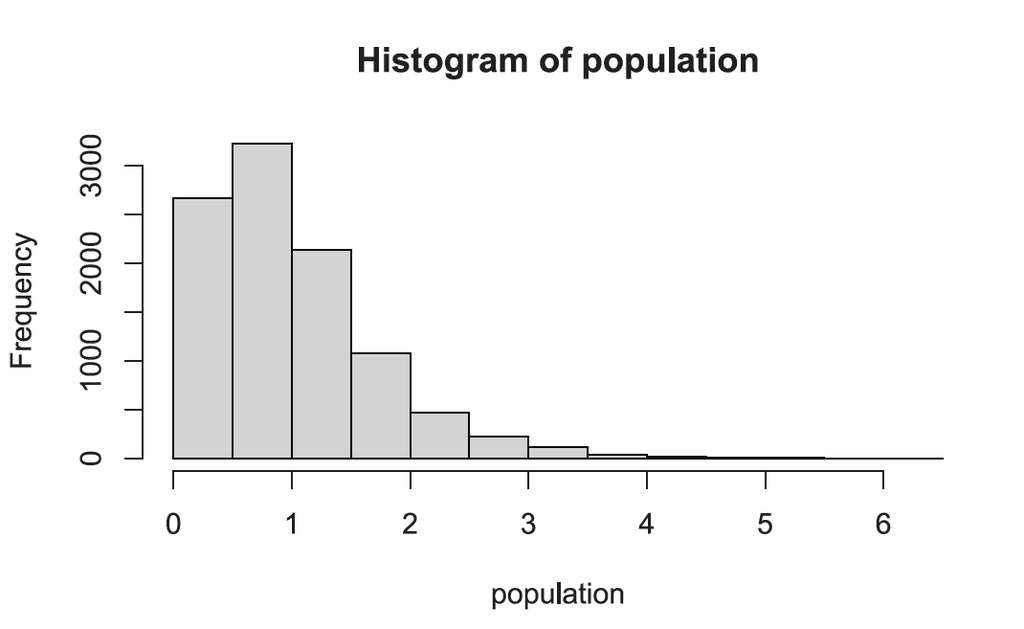

- Consider taking many random samples of $n = 10$ responses
- What shape will the distribution of sample means have when $n = 10$?

## Simulated Example

**One Sample** ($n= 10$)

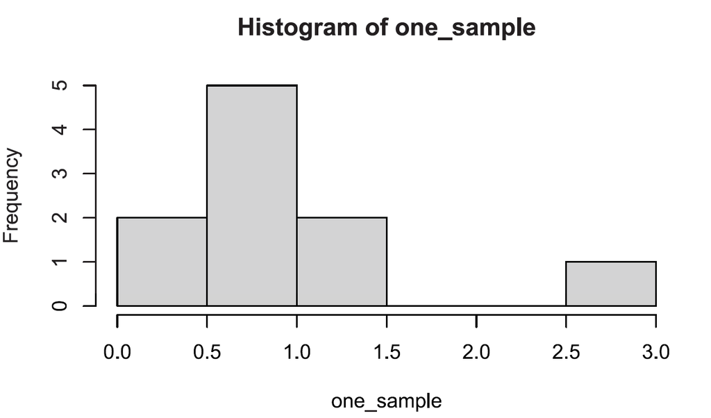

- One sample of 10 responses is also very right skewed with a sample mean of $\bar{x} = 0.893$

```r
mean(one_sample)
# [1] 0.8927883
```

- Now take many, many samples of size $n=10$

## Simulated Example

**Sampling Distribution** ($n= 10$)

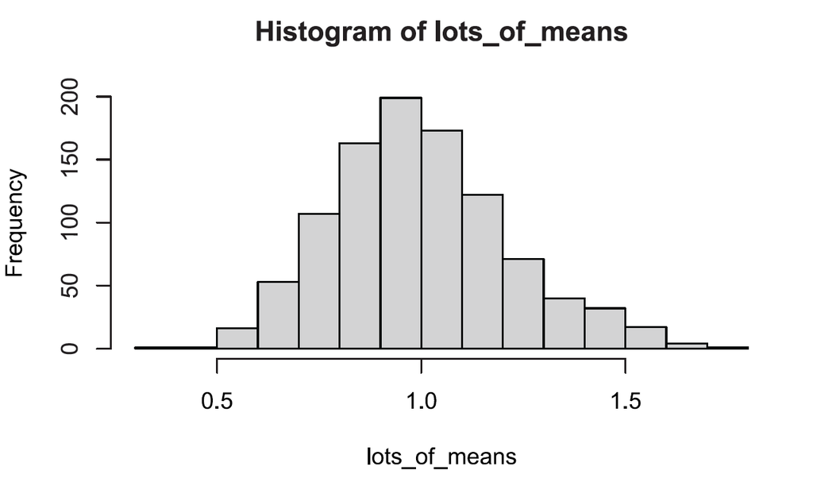

- Here we simulated 1000 different samples of size $n=10$
- Get an $\bar{x}$ for each sample
- For $n=10$, the distribution of sample means is still right skewed!
- **Takeaway:** $n=10$ doesn’t look big enough to apply CLT!

## Simulation: Increase $n$!

**Population**

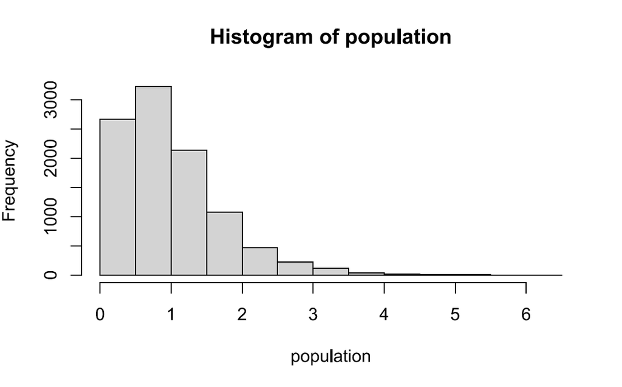

- Population of responses is very right skewed with a population mean of $\mu = 0.998$
- Consider taking many random samples of **n = 50** responses
- What shape will the distribution of sample means have when $n =50$?

## Simulation: Increase n!

**One Sample** (n=50)

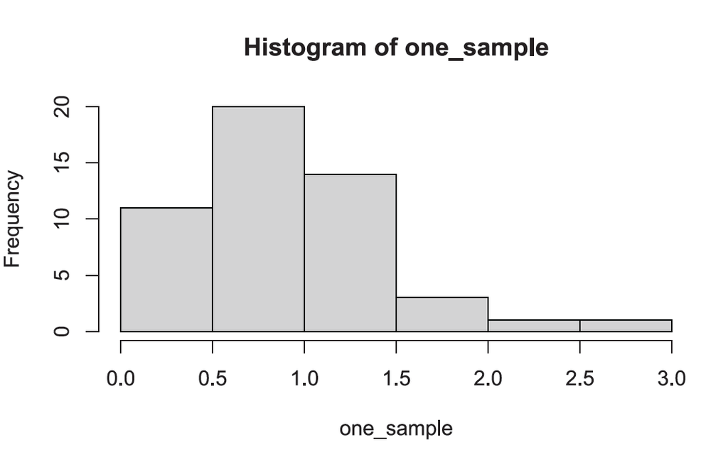

- Sample of 50 responses is also very right skewed with a sample mean of $\bar{x} = 0.905$

```r
mean(one_sample)
# [1] 0.9046072
```

- Now take many, many samples of size $n=50$

## Simulation: Increase n!

**Sampling Distribution** (n=50)

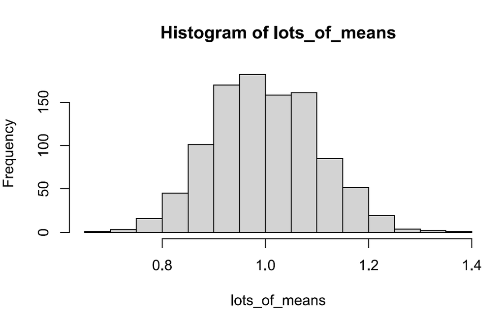

- Here we simulated 1000 different samples of size $n=50$
- Get an $\bar{x}$ for each
- For $n=50$, the distribution of sample means is no longer right skewed
- **Takeaway:** $n=50$ is big enough for CLT!

## Summary

- We don’t need the **sample** to be symmetric/bell-shaped!
- But if the population (and therefore likely sample) are **skewed**, we should be careful that the sample size is big enough, so that the sampling distribution would be symmetric/bell-shaped
- The CLT is used to estimate the SE of sample *statistics*, not the sample values

# SE for Means

## SE for Means

**SE for One Mean**

SE for $\bar{x}$ is
$$SE_{\bar{x}} = \frac{\sigma}{\sqrt{n}}$$

where $\sigma$ is the population SD of your response

**SE for Two Means**

SE for $\bar{x}_1 - \bar{x}_2$ is

$$SE_{\bar{x}_1 - \bar{x}_2} = \sqrt{\frac{\sigma_1^2}{n_1} + \frac{\sigma^2_2}{n_2}}$$

**Issue**

Usually we do not know $\sigma$! We estimate $\sigma$ with sample SD, $s$.

## SE for Means

**Estimated SE for One Mean**

Estimated SE for $\bar{x}$ is
$$SE_{\bar{x}} = \frac{s}{\sqrt{n}}$$

where $s$ is the sample SD of your response

**Estimated SE for Two Means**

Estimated SE for $\bar{x}_1 - \bar{x}_2$ is

$$SE_{\bar{x}_1 - \bar{x}_2} = \sqrt{\frac{s_1^2}{n_1} + \frac{s^2_2}{n_2}}$$

## Problem!

The **estimated** SE varies from sample to sample, along with $\bar{x}$!

**$\sigma$ known**

For $z$, only $\bar{x}$ varies from sample to sample

$$z = \frac{\bar{x} - \mu}{\sigma / \sqrt{n}} \sim N(0,1)$$

**$\sigma$ unknown**

For $t$, both $\bar{x}$ and $s$ vary from sample to sample

$$t = \frac{\bar{x} - \mu}{\color{blue}{s}/\sqrt{n}} \sim ???$$

## Solution: The $t$- distribution

The standardized t-statistic has a **“t” distribution** with df degrees of freedom

$$t = \frac{\bar{x} - \mu}{s/\sqrt{n}} \sim t_{\color{blue}{df}}$$

- The $t$ distribution is very similar to the standard normal, but with slightly fatter tails to reflect the added uncertainty in the denominator.

## $t$ distribution and degrees of freedom

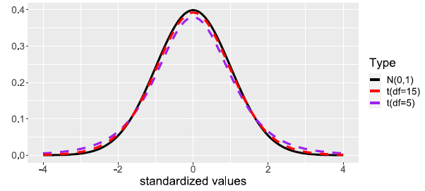

## $t$ distribution and degrees of freedom

**Degrees of Freedom**

- The degrees of freedom tells us which t-distribution to use
- As $df$ increases, $t_{df}$ distribution looks more like a $N(0,1)$ distribution
- **One sample:** $df =$ $n-1$
- **Two sample:** use technology to find $df$
  - Conservative approach: $df = min(n_1 - 1, n_2 - 1)$

## Procedure: Inference for Means, Hyp Testing

- **Check** the one- or two-sample size conditions for the CLT
- **Hypothesis Tests:** Use $t$-ratios of the form
  $$t = \frac{\text{stat} - \text{null value}}{SE}$$
- P-values computed from a t-distribution with appropriate $df$
  - **pt(t, df= )** gives the area to the left of $t$

## Procedure: Inference for Means, CI

- **Check** the one- or two-sample size conditions for the CLT
- **Confidence Intervals:** CI of the form

$$\text{stat} \pm t^* (SE)$$

- $t^*$ multiplier comes from a t-distribution with appropriate $df$
  - **qt(0.975, df = )** gives $t^*$ for 95% confidence

# HT Example

## Example: Florida Lakes

- 53 lakes were sampled, pH recorded, $\sigma$ unknown
- **Question:** Is average pH in Florida lakes different from 7 (neutral)?

**Hypotheses**

- Let $\mu$ be the mean pH for all Florida lakes
- $H_0: \mu = 7$ and $H_a: \mu \neq 7$

Can we use a t-test?

- $n=53$ is a decent sample size
- Check sample distribution of pHs

## Florida Lakes

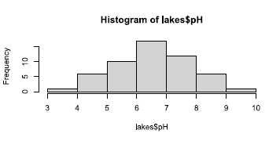

```r
lakes <- read.csv("https://www.lock5stat.com/datasets1e/FloridaLakes.csv")
hist(lakes$pH)
```

- sampled pH’s roughly symmetric, so $n=53$ is “big enough” for the CLT
- Data: $\bar{x} = 6.591, s = 1.288$

```r
mean(lakes$pH)
```

```
[1] 6.590566
```

```r
sd(lakes$pH)
```

```
[1] 1.288449
```

## Florida Lakes

$H_0:$ $\mu = 7$ and $H_a:$ $\mu \neq 7$

- **Calculate test statistic:**

  $$t = \frac{6.591 - 7}{1.288/\sqrt{53}} \approx -2.31$$
- **Interpret t**: The observed mean pH of 6.591 is 2.31 SEs below the null value of 7.
- **Calculate p-value:** $2 \times P(t < -2.31)$, or double left tail area below -2.31
  - Use t-distribution with $df = 53-1 = 52$

```r
2*pt(_________, df=________) # df = n-1
## [1] 0.02489032
```

## Florida Lakes

- **Interpret p-value:** The p-value is 0.025. If the mean pH of all lakes is 7, then we would see a sample mean pH that is at least 2.31 SEs away from 7 about 2.5% of the time in samples of 53 lakes.
- **Conclusion:** There is a statistically discernible difference between the observed mean pH of 6.591 and the hypothesized mean of 7 (t=-2.31, df=52, p=0.025).

# CI Example

## Florida Lakes

**CI Example**

How different is the population mean from 7?

- Can calculate a 95% CI for $\mu$
- What is the value for $t^*$?
  - $t^*$ corresponds to 95% confidence (97.5th percentile):

```r
qt(________, df=________)
## [1] 2.006647
```

- Let’s put the pieces together to calculate a CI:
  $$6.591 \pm 2.0066 (\frac{1.288}{\sqrt{53}}) = 6.591 \pm 0.355 = (6.236, 6.946)$$
- **Interpretation:** We are 95% confident that the mean pH of all lakes is between 6.236 and 6.946 (slightly acidic).

## Florida Lakes

We can also use the function t.test!

```r
t.test(lakes$pH, mu = 7)
```

```
    One Sample t-test

data:  lakes$pH
t = -2.3134, df = 52, p-value = 0.02469
alternative hypothesis: true mean is not equal to 7
95 percent confidence interval:
 6.235425 6.945707
sample estimates:
mean of x
 6.590566
```

## Example: Video Games and GPA

**Context**

210 first-year college students were *randomly assigned* roommates

**Data**

- For the 78 students assigned to roommates who brought a videogame to college: average GPA after the first semester was 2.84, with a standard deviation of 0.669.
- For the 132 students assigned to roommates who did not bring a videogame to college, average GPA after the first semester was 3.105, with a standard deviation of 0.625.

**Question**

How much does getting assigned a roommate who brings a videogame to college affect your first semester GPA? Find a 90% CI.

## Identifying Statistics

- For the 78 students assigned to roommates who brought a videogame to college: average GPA after the first semester was 2.84, with a standard deviation of 0.669.
- For the 132 students assigned to roommates who did not bring a videogame to college, average GPA after the first semester was 3.105, with a standard deviation of 0.625.

Identify the following quantities:

- $s_1$, $s_2$, $n_1$, $n_2$, $\bar{x}_1$, $\bar{x}_2$

## Create a 90% CI

$$\text{stat} \pm t^* (SE)$$

- Statistic: $\bar{x}_1 - \bar{x}_2 = 2.84 - 3.105 = -0.265$
- $df$ found using conservative approach: $min(n_1 - 1, n_2 - 1)$ $= 77$
- $t^*$ found using R

```r
qt(________, df = _____)
#[1] 1.664885
```

- SE: $\sqrt{\frac{s_1^2}{n_1} + \frac{s^2_2}{n_2}} =$ $\sqrt{\frac{0.669^2}{78} + \frac{0.625^2}{132}} = 0.0932590$
- 90% CI: $-0.265 \pm 1.665 \times 0.0933 = (-0.419, -0.111)$
- **Interpretation**: We are 90% confident that getting assigned a roommate who brings a videogame to college decreases the mean first semester GPA by between 0.11 to 0.42 points.

# Summary

## Step by Step Procedure: Hypothesis Testing

1. State Hypotheses and Define Parameters
2. Check Conditions for Sample Size

   **Proportions:** $np$ and $n(1-p) \geq 10$ for all groups for two sample  
   **Means**: $n \geq 30$ for all groups for two sample  
   Check distribution of sample if small sample size
3. Calculate Statistic (from sample)

   **Proportions:** $\hat{p}$, $\hat{p}_1 - \hat{p}_2$ **Means**: $\bar{x}$, $\bar{x}_1 - \bar{x}_2$
4. Calculate Standard Error

   **One Proportion:** $SE = \sqrt{\frac{p_0(1-p_0)}{n}}$  
   **Two Proportions:** $SE = \sqrt{\frac{p_{pool}(1-p_{pool})}{n_1}+\frac{p_{pool}(1-p_{pool})}{n_2}}$

   **One Mean**: $SE = s/\sqrt{n}$ ($\sigma$ unknown) OR $SE = \sigma/\sqrt{n}$  
   **Two Means**: $SE = \sqrt{\frac{s_1^2}{n_1} + \frac{s^2_2}{n_2}}$ ($\sigma$ unknown) OR $SE = \sqrt{\frac{\sigma_1^2}{n_1} + \frac{\sigma^2_2}{n_2}}$

## Step by Step Procedure: Hypothesis Testing

5. Calculate standardized test statistic based on (1), (3), and (4)
   $$\frac{\text{stat } (3) - \text{null value } (1)}{SE \text{ }(4)}$$
6. Compute p-value

   Based on $N(0,1)$ and standardized test statistic  
   **Except** if $\sigma$ unknown for means, then use $t_{df}$, $df = n-1$
7. Interpret in context with conclusion

## Step by Step Procedure: Confidence Interval

1. Check the one- or two-sample size conditions for the CLT
2. Create CI based on $\text{stat} \pm \text{multip}^* \times SE$

   Mutliplier: $z^*$ based $N(0,1)$  
   **Except** when $\sigma$ unknown, then use $t^*$ based on $t_{df}$

   **One Proportion:** $SE = \sqrt{\frac{\hat{p}(1-\hat{p})}{n}}$  
   **Two Proportions:** $SE = \sqrt{\frac{\hat{p}_1(1-\hat{p}_1)}{n_1}+\frac{\hat{p}_2(1-\hat{p}_2)}{n_2}}$

   **One Mean**: $SE = s/\sqrt{n}$ ($\sigma$ unknown) OR $SE = \sigma/\sqrt{n}$  
   **Two Means**: $SE = \sqrt{\frac{s_1^2}{n_1} + \frac{s^2_2}{n_2}}$ ($\sigma$ unknown) OR $SE = \sqrt{\frac{\sigma_1^2}{n_1} + \frac{\sigma^2_2}{n_2}}$
3. Interpret in Context

## Useful R Functions

```r
#gives you P(Z<= 2.82) for standard normal, can use to find p-values
pnorm(2.82)
```

```
[1] 0.9975988
```

```r
#gives you P(Z<= 2.82) for NOT standard normal, can also use to find p-values
pnorm(2.82, mean = 3, sd =2)
```

```
[1] 0.4641436
```

```r
#gives you z* for 95% CI
qnorm(0.975)
```

```
[1] 1.959964
```

```r
#gives you t* value for 90% CI
qt(0.95, df = 131)
```

```
[1] 1.656569
```

```r
#conducts t.test for one mean, with specified null hypothesis
t.test(lakes$pH, mu = 7)
#can change alternative hypothesis
t.test(lakes$pH, mu = 7, alternative = "less")

#two-sample t-test
t.test(numeric ~ factor, data = df)
```

## In-Class R Example

In your groups (1 RStudio open per group), work through a-e of the API exercise. There is R code on Moodle!

## Next Class

Wrap up Chapter 6, Start on Chapter 7: Chi-Square Tests for Categorical Variables

(Multiple Parameters)